# Housing Prices in Iowa

Let’s start by grabbing the packages we are going to use.

```r
library(corrr)
library(rcompanion)
library(tidyverse)
library(mice)
library(VIM)
library(SignifReg)
library(car)
library(corrplot)
library(randomForest)
```

Next, we can read the data we will be using.

```r
train <- read.csv('train.csv', header=TRUE)
test <- read.csv('test.csv', header=TRUE)
sample_submission <- read.csv("sample_submission.csv", header = TRUE)
```

So we have our data now, what is the first thing we should do? We need it inspect it and get a general idea of what’s going on

```r
train
```

| Id | MSSubClass | MSZoning | LotFrontage | LotArea | Street | Alley | LotShape | LandContour | Utilities | LotConfig | LandSlope | Neighborhood | Condition1 | Condition2 | BldgType | HouseStyle | OverallQual | OverallCond | YearBuilt | YearRemodAdd | RoofStyle | RoofMatl | Exterior1st | Exterior2nd | MasVnrType | MasVnrArea | ExterQual | ExterCond | Foundation | … |
| --- | --- | --- | --- | --- | --- | --- | --- | --- | --- | --- | --- | --- | --- | --- | --- | --- | --- | --- | --- | --- | --- | --- | --- | --- | --- | --- | --- | --- | --- | --- |
| 1 | 60 | RL | 65 | 8450 | Pave | NA | Reg | Lvl | AllPub | Inside | Gtl | CollgCr | Norm | Norm | 1Fam | 2Story | 7 | 5 | 2003 | 2003 | Gable | CompShg | VinylSd | VinylSd | BrkFace | 196 | Gd | TA | PConc | … |
| 2 | 20 | RL | 80 | 9600 | Pave | NA | Reg | Lvl | AllPub | FR2 | Gtl | Veenker | Feedr | Norm | 1Fam | 1Story | 6 | 8 | 1976 | 1976 | Gable | CompShg | MetalSd | MetalSd | None | 0 | TA | TA | CBlock | … |
| 3 | 60 | RL | 68 | 11250 | Pave | NA | IR1 | Lvl | AllPub | Inside | Gtl | CollgCr | Norm | Norm | 1Fam | 2Story | 7 | 5 | 2001 | 2002 | Gable | CompShg | VinylSd | VinylSd | BrkFace | 162 | Gd | TA | PConc | … |
| 4 | 70 | RL | 60 | 9550 | Pave | NA | IR1 | Lvl | AllPub | Corner | Gtl | Crawfor | Norm | Norm | 1Fam | 2Story | 7 | 5 | 1915 | 1970 | Gable | CompShg | Wd Sdng | Wd Shng | None | 0 | TA | TA | BrkTil | … |
| 5 | 60 | RL | 84 | 14260 | Pave | NA | IR1 | Lvl | AllPub | FR2 | Gtl | NoRidge | Norm | Norm | 1Fam | 2Story | 8 | 5 | 2000 | 2000 | Gable | CompShg | VinylSd | VinylSd | BrkFace | 350 | Gd | TA | PConc | … |
| 6 | 50 | RL | 85 | 14115 | Pave | NA | IR1 | Lvl | AllPub | Inside | Gtl | Mitchel | Norm | Norm | 1Fam | 1.5Fin | 5 | 5 | 1993 | 1995 | Gable | CompShg | VinylSd | VinylSd | None | 0 | TA | TA | Wood | … |
| 7 | 20 | RL | 75 | 10084 | Pave | NA | Reg | Lvl | AllPub | Inside | Gtl | Somerst | Norm | Norm | 1Fam | 1Story | 8 | 5 | 2004 | 2005 | Gable | CompShg | VinylSd | VinylSd | Stone | 186 | Gd | TA | PConc | … |
| 8 | 60 | RL | NA | 10382 | Pave | NA | IR1 | Lvl | AllPub | Corner | Gtl | NWAmes | PosN | Norm | 1Fam | 2Story | 7 | 6 | 1973 | 1973 | Gable | CompShg | HdBoard | HdBoard | Stone | 240 | TA | TA | CBlock | … |
| 9 | 50 | RM | 51 | 6120 | Pave | NA | Reg | Lvl | AllPub | Inside | Gtl | OldTown | Artery | Norm | 1Fam | 1.5Fin | 7 | 5 | 1931 | 1950 | Gable | CompShg | BrkFace | Wd Shng | None | 0 | TA | TA | BrkTil | … |
| 10 | 190 | RL | 50 | 7420 | Pave | NA | Reg | Lvl | AllPub | Corner | Gtl | BrkSide | Artery | Artery | 2fmCon | 1.5Unf | 5 | 6 | 1939 | 1950 | Gable | CompShg | MetalSd | MetalSd | None | 0 | TA | TA | BrkTil | … |

[output cut: 990 more lines]

```r
NA
```

```r
test
```

| Id | MSSubClass | MSZoning | LotFrontage | LotArea | Street | Alley | LotShape | LandContour | Utilities | LotConfig | LandSlope | Neighborhood | Condition1 | Condition2 | BldgType | HouseStyle | OverallQual | OverallCond | YearBuilt | YearRemodAdd | RoofStyle | RoofMatl | Exterior1st | Exterior2nd | MasVnrType | MasVnrArea | ExterQual | ExterCond | Foundation | … |
| --- | --- | --- | --- | --- | --- | --- | --- | --- | --- | --- | --- | --- | --- | --- | --- | --- | --- | --- | --- | --- | --- | --- | --- | --- | --- | --- | --- | --- | --- | --- |
| 1461 | 20 | RH | 80 | 11622 | Pave | NA | Reg | Lvl | AllPub | Inside | Gtl | NAmes | Feedr | Norm | 1Fam | 1Story | 5 | 6 | 1961 | 1961 | Gable | CompShg | VinylSd | VinylSd | None | 0 | TA | TA | CBlock | … |
| 1462 | 20 | RL | 81 | 14267 | Pave | NA | IR1 | Lvl | AllPub | Corner | Gtl | NAmes | Norm | Norm | 1Fam | 1Story | 6 | 6 | 1958 | 1958 | Hip | CompShg | Wd Sdng | Wd Sdng | BrkFace | 108 | TA | TA | CBlock | … |
| 1463 | 60 | RL | 74 | 13830 | Pave | NA | IR1 | Lvl | AllPub | Inside | Gtl | Gilbert | Norm | Norm | 1Fam | 2Story | 5 | 5 | 1997 | 1998 | Gable | CompShg | VinylSd | VinylSd | None | 0 | TA | TA | PConc | … |
| 1464 | 60 | RL | 78 | 9978 | Pave | NA | IR1 | Lvl | AllPub | Inside | Gtl | Gilbert | Norm | Norm | 1Fam | 2Story | 6 | 6 | 1998 | 1998 | Gable | CompShg | VinylSd | VinylSd | BrkFace | 20 | TA | TA | PConc | … |
| 1465 | 120 | RL | 43 | 5005 | Pave | NA | IR1 | HLS | AllPub | Inside | Gtl | StoneBr | Norm | Norm | TwnhsE | 1Story | 8 | 5 | 1992 | 1992 | Gable | CompShg | HdBoard | HdBoard | None | 0 | Gd | TA | PConc | … |
| 1466 | 60 | RL | 75 | 10000 | Pave | NA | IR1 | Lvl | AllPub | Corner | Gtl | Gilbert | Norm | Norm | 1Fam | 2Story | 6 | 5 | 1993 | 1994 | Gable | CompShg | HdBoard | HdBoard | None | 0 | TA | TA | PConc | … |
| 1467 | 20 | RL | NA | 7980 | Pave | NA | IR1 | Lvl | AllPub | Inside | Gtl | Gilbert | Norm | Norm | 1Fam | 1Story | 6 | 7 | 1992 | 2007 | Gable | CompShg | HdBoard | HdBoard | None | 0 | TA | Gd | PConc | … |
| 1468 | 60 | RL | 63 | 8402 | Pave | NA | IR1 | Lvl | AllPub | Inside | Gtl | Gilbert | Norm | Norm | 1Fam | 2Story | 6 | 5 | 1998 | 1998 | Gable | CompShg | VinylSd | VinylSd | None | 0 | TA | TA | PConc | … |
| 1469 | 20 | RL | 85 | 10176 | Pave | NA | Reg | Lvl | AllPub | Inside | Gtl | Gilbert | Norm | Norm | 1Fam | 1Story | 7 | 5 | 1990 | 1990 | Gable | CompShg | HdBoard | HdBoard | None | 0 | TA | TA | PConc | … |
| 1470 | 20 | RL | 70 | 8400 | Pave | NA | Reg | Lvl | AllPub | Corner | Gtl | NAmes | Norm | Norm | 1Fam | 1Story | 4 | 5 | 1970 | 1970 | Gable | CompShg | Plywood | Plywood | None | 0 | TA | TA | CBlock | … |

[output cut: 990 more lines]

```r
NA
```

It looks like we are missing quite a bit of data, let’s see exactly how much of it is missing starting with the training set.

```r
pMiss <- function(x){sum(is.na(x))/length(x)*100}
apply(train,2,pMiss)
```

```
           Id    MSSubClass      MSZoning   LotFrontage       LotArea        Street         Alley      LotShape   LandContour     Utilities
   0.00000000    0.00000000    0.00000000   17.73972603    0.00000000    0.00000000   93.76712329    0.00000000    0.00000000    0.00000000
    LotConfig     LandSlope  Neighborhood    Condition1    Condition2      BldgType    HouseStyle   OverallQual   OverallCond     YearBuilt
   0.00000000    0.00000000    0.00000000    0.00000000    0.00000000    0.00000000    0.00000000    0.00000000    0.00000000    0.00000000
 YearRemodAdd     RoofStyle      RoofMatl   Exterior1st   Exterior2nd    MasVnrType    MasVnrArea     ExterQual     ExterCond    Foundation
   0.00000000    0.00000000    0.00000000    0.00000000    0.00000000    0.54794521    0.54794521    0.00000000    0.00000000    0.00000000
     BsmtQual      BsmtCond  BsmtExposure  BsmtFinType1    BsmtFinSF1  BsmtFinType2    BsmtFinSF2     BsmtUnfSF   TotalBsmtSF       Heating
   2.53424658    2.53424658    2.60273973    2.53424658    0.00000000    2.60273973    0.00000000    0.00000000    0.00000000    0.00000000
    HeatingQC    CentralAir    Electrical     X1stFlrSF     X2ndFlrSF  LowQualFinSF     GrLivArea  BsmtFullBath  BsmtHalfBath      FullBath
   0.00000000    0.00000000    0.06849315    0.00000000    0.00000000    0.00000000    0.00000000    0.00000000    0.00000000    0.00000000
     HalfBath  BedroomAbvGr  KitchenAbvGr   KitchenQual  TotRmsAbvGrd    Functional    Fireplaces   FireplaceQu    GarageType   GarageYrBlt
   0.00000000    0.00000000    0.00000000    0.00000000    0.00000000    0.00000000    0.00000000   47.26027397    5.54794521    5.54794521
 GarageFinish    GarageCars    GarageArea    GarageQual    GarageCond    PavedDrive    WoodDeckSF   OpenPorchSF EnclosedPorch    X3SsnPorch
   5.54794521    0.00000000    0.00000000    5.54794521    5.54794521    0.00000000    0.00000000    0.00000000    0.00000000    0.00000000
  ScreenPorch      PoolArea        PoolQC         Fence   MiscFeature       MiscVal        MoSold        YrSold      SaleType SaleCondition
   0.00000000    0.00000000   99.52054795   80.75342466   96.30136986    0.00000000    0.00000000    0.00000000    0.00000000    0.00000000
    SalePrice
   0.00000000
```

We can start imputing some of this data with the MICE function

```r
mice_train <- mice(train, m=5, maxit=50, method = "pmm", seed = 500)
```

```
Number of logged events: 1543
```

```r
mice_train_full <- complete(mice_train, 1)
```

So we imputed the missing values using the predictive mean matching method from MICE on 3 columns: LotFrontage, MasVnrArea, and GarageYrBlt. Now we should deal with the rest of the NA’s by converting them to 0’s since that will be easier to work with. We can quickly see if the rest are marked as being criteria in the data description quickly by creating a function to check for NA in each column.

```r
na_count_train_test <-sapply(mice_train_full, function(y) sum(length(which(is.na(y)))))
na_count_train_test <- data.frame(na_count_train_test)
na_count_train_test
```

|  | na_count_train_test |
| --- | --- |
| Id | 0 |
| MSSubClass | 0 |
| MSZoning | 0 |
| LotFrontage | 0 |
| LotArea | 0 |
| Street | 0 |
| Alley | 1369 |
| LotShape | 0 |
| LandContour | 0 |
| Utilities | 0 |

[output cut: 71 more lines]

```r
NA
```

Two categories stick out that don’t use NA as a criteria, MasVnrType and Electrical. We can start with MasVnrType and use mode imputation since there is only 8 missing values.

```r
MasVnrType_val <- unique(mice_train_full$MasVnrType[!is.na(mice_train_full$MasVnrType)])
MasVnrType_mode <- MasVnrType_val[which.max(tabulate(match(mice_train_full$MasVnrType, MasVnrType_val)))]
MasVnrType_imp <- mice_train_full$MasVnrType
MasVnrType_imp[is.na(MasVnrType_imp)] <- MasVnrType_mode
mice_train_full$MasVnrType <- MasVnrType_imp
```

We will do the same thing for Electrical, mode imputation, since it is only 1 variable missing.

```r
table(mice_train_full$Electrical)
```

```
FuseA FuseF FuseP   Mix SBrkr
   94    27     3     1  1334
```

```r
mice_train_full$Electrical[is.na(mice_train_full$Electrical)] <- "SBrkr"
```

The rest have NA as a level so we will just swap those with O’s now.

```r
mice_train_full$BsmtQual[is.na(mice_train_full$BsmtQual)] <- 0
mice_train_full$BsmtCond[is.na(mice_train_full$BsmtCond)] <- 0
mice_train_full$BsmtCond[is.na(mice_train_full$BsmtExposure)] <- 0
mice_train_full$BsmtFinType1[is.na(mice_train_full$BsmtFinType1)] <- 0
mice_train_full$BsmtFinType2[is.na(mice_train_full$BsmtFinType2)] <- 0
mice_train_full$BsmtExposure[is.na(mice_train_full$BsmtExposure)] <- 0
mice_train_full$Alley[is.na(mice_train_full$Alley)] <- 0
mice_train_full$FireplaceQu[is.na(mice_train_full$FireplaceQu)] <- 0
mice_train_full$GarageType[is.na(mice_train_full$GarageType)] <- 0
mice_train_full$GarageFinish[is.na(mice_train_full$GarageFinish)] <- 0
mice_train_full$GarageQual[is.na(mice_train_full$GarageQual)] <- 0
mice_train_full$GarageCond[is.na(mice_train_full$GarageCond)] <- 0
mice_train_full$PoolQC[is.na(mice_train_full$PoolQC)] <- 0
mice_train_full$Fence[is.na(mice_train_full$Fence)] <- 0
mice_train_full$MiscFeature[is.na(mice_train_full$MiscFeature)] <- 0
```

Now that all the necessary data is imputed we can convert these characters to factors, since we need them to be factors to run models.

```r
mice_train_full$MSSubClass <- as.character(mice_train_full$MSSubClass)
mice_train_full$Id <- as.character(mice_train_full$Id)
mice_train_full$OverallQual <- as.character(mice_train_full$OverallQual)
mice_train_full$OverallCond <- as.character(mice_train_full$OverallCond)
mice_train_full$YearBuilt <- as.character(mice_train_full$YearBuilt)
mice_train_full$YearRemodAdd <- as.character(mice_train_full$YearRemodAdd)
mice_train_full$BsmtFullBath <- as.character(mice_train_full$BsmtFullBath)
mice_train_full$BsmtHalfBath <- as.character(mice_train_full$BsmtHalfBath)
mice_train_full$FullBath <- as.character(mice_train_full$FullBath)
mice_train_full$HalfBath <- as.character(mice_train_full$HalfBath)
mice_train_full$BedroomAbvGr <- as.character(mice_train_full$BedroomAbvGr)
mice_train_full$KitchenAbvGr <- as.character(mice_train_full$KitchenAbvGr)
mice_train_full$TotRmsAbvGrd <- as.character(mice_train_full$TotRmsAbvGrd)
mice_train_full$Fireplaces <- as.character(mice_train_full$Fireplaces)
mice_train_full$GarageYrBlt <- as.character(mice_train_full$GarageYrBlt)
mice_train_full$GarageCars <- as.character(mice_train_full$GarageCars)
mice_train_full$MoSold <- as.character(mice_train_full$MoSold)
mice_train_full$YrSold <- as.character(mice_train_full$YrSold)

mice_train_full[sapply(mice_train_full, is.character)] <- lapply(mice_train_full[sapply(mice_train_full, is.character)], as.factor)
```

```r
apply(train,2,pMiss)
```

```
           Id    MSSubClass      MSZoning   LotFrontage       LotArea        Street         Alley      LotShape   LandContour     Utilities
   0.00000000    0.00000000    0.00000000   17.73972603    0.00000000    0.00000000   93.76712329    0.00000000    0.00000000    0.00000000
    LotConfig     LandSlope  Neighborhood    Condition1    Condition2      BldgType    HouseStyle   OverallQual   OverallCond     YearBuilt
   0.00000000    0.00000000    0.00000000    0.00000000    0.00000000    0.00000000    0.00000000    0.00000000    0.00000000    0.00000000
 YearRemodAdd     RoofStyle      RoofMatl   Exterior1st   Exterior2nd    MasVnrType    MasVnrArea     ExterQual     ExterCond    Foundation
   0.00000000    0.00000000    0.00000000    0.00000000    0.00000000    0.54794521    0.54794521    0.00000000    0.00000000    0.00000000
     BsmtQual      BsmtCond  BsmtExposure  BsmtFinType1    BsmtFinSF1  BsmtFinType2    BsmtFinSF2     BsmtUnfSF   TotalBsmtSF       Heating
   2.53424658    2.53424658    2.60273973    2.53424658    0.00000000    2.60273973    0.00000000    0.00000000    0.00000000    0.00000000
    HeatingQC    CentralAir    Electrical     X1stFlrSF     X2ndFlrSF  LowQualFinSF     GrLivArea  BsmtFullBath  BsmtHalfBath      FullBath
   0.00000000    0.00000000    0.06849315    0.00000000    0.00000000    0.00000000    0.00000000    0.00000000    0.00000000    0.00000000
     HalfBath  BedroomAbvGr  KitchenAbvGr   KitchenQual  TotRmsAbvGrd    Functional    Fireplaces   FireplaceQu    GarageType   GarageYrBlt
   0.00000000    0.00000000    0.00000000    0.00000000    0.00000000    0.00000000    0.00000000   47.26027397    5.54794521    5.54794521
 GarageFinish    GarageCars    GarageArea    GarageQual    GarageCond    PavedDrive    WoodDeckSF   OpenPorchSF EnclosedPorch    X3SsnPorch
   5.54794521    0.00000000    0.00000000    5.54794521    5.54794521    0.00000000    0.00000000    0.00000000    0.00000000    0.00000000
  ScreenPorch      PoolArea        PoolQC         Fence   MiscFeature       MiscVal        MoSold        YrSold      SaleType SaleCondition
   0.00000000    0.00000000   99.52054795   80.75342466   96.30136986    0.00000000    0.00000000    0.00000000    0.00000000    0.00000000
    SalePrice
   0.00000000
```

```r
mice_test <- mice(test, m=5,maxit=50,meth='pmm',seed=500)
```

```
Number of logged events: 5543
```

```r
mice_test_full <- complete(mice_test,1)
```

Let’s check for the NA’s now.

```r
na_count_test_test <-sapply(mice_test_full, function(y) sum(length(which(is.na(y)))))
na_count_test_test <- data.frame(na_count_test_test)
na_count_test_test
```

|  | na_count_test_test |
| --- | --- |
| Id | 0 |
| MSSubClass | 0 |
| MSZoning | 4 |
| LotFrontage | 0 |
| LotArea | 0 |
| Street | 0 |
| Alley | 1352 |
| LotShape | 0 |
| LandContour | 0 |
| Utilities | 2 |

[output cut: 70 more lines]

```r
NA
```

This time we have to deal with **MSZoning**, **Utilities**, **Exterior1st**, **Exterior2nd**, **KitchenQual**, **Functional**, and **SaleType**. Starting with MSZoning, let’s figure out the mode.

```r
table(mice_test_full$MSZoning, useNA = "ifany")
```

```
C (all)      FV      RH      RL      RM    <NA>
     15      74      10    1114     242       4
```

Mode imputation

```r
mice_test_full$MSZoning[is.na(mice_test_full$MSZoning)] <- "RL"
```

For Utilities

```r
table(mice_test_full$Utilities, useNA = "ifany")
```

```
AllPub   <NA>
  1457      2
```

Mode imputation

```r
mice_test_full$Utilities[is.na(mice_test_full$Utilities)] <- "AllPub"
```

For Exterior1st, and I’m going to assume Exterior2nd follows the same pattern here. We will want to check for multicollinearity on this later for sure.

```r
table(mice_test_full$Exterior1st, useNA = "ifany")
```

```
AsbShng AsphShn BrkComm BrkFace  CBlock CemntBd HdBoard MetalSd Plywood  Stucco VinylSd Wd Sdng WdShing    <NA>
     24       1       4      37       1      65     220     230     113      18     510     205      30       1
```

```r
table(mice_test_full$Exterior2nd, useNA = "ifany")
```

```
AsbShng AsphShn Brk Cmn BrkFace  CBlock CmentBd HdBoard ImStucc MetalSd Plywood   Stone  Stucco VinylSd Wd Sdng Wd Shng    <NA>
     18       1      15      22       2      66     199       5     233     128       1      21     510     194      43       1
```

Slightly different, but we are still going to impute the mode which is the same for both.

```r
mice_test_full$Exterior1st[is.na(mice_test_full$Exterior1st)] <- "VinylSd"
mice_test_full$Exterior2nd[is.na(mice_test_full$Exterior2nd)] <- "VinylSd"
```

For KitchenQual

```r
table(mice_test_full$KitchenQual, useNA = "ifany")
```

```
  Ex   Fa   Gd   TA <NA>
 105   31  565  757    1
```

```r
mice_test_full$KitchenQual[is.na(mice_test_full$KitchenQual)] <- "TA"
```

For Functional

```r
table(mice_test_full$Functional, useNA = "ifany")
```

```
Maj1 Maj2 Min1 Min2  Mod  Sev  Typ <NA>
   5    4   34   36   20    1 1357    2
```

```r
mice_test_full$Functional[is.na(mice_test_full$Functional)] <- "Typ"
```

And finally, SaleType

```r
table(mice_test_full$SaleType, useNA = "ifany")
```

```
  COD   Con ConLD ConLI ConLw   CWD   New   Oth    WD  <NA>
   44     3    17     4     3     8   117     4  1258     1
```

```r
mice_test_full$Functional[is.na(mice_test_full$Functional)] <- "WD"
```

Now let’s swap the rest of the NA’s that are valid with 0’s and then convert them to factors.

```r
mice_test_full[is.na(mice_test_full)] <- 0
mice_test_full[sapply(mice_test_full, is.character)] <- lapply(mice_test_full[sapply(mice_test_full, is.character)], as.factor)
mice_test_full$GarageCars <- as.factor(mice_test_full$GarageCars)
mice_test_full$Fireplaces <- as.factor(mice_test_full$Fireplaces)
mice_test_full$TotRmsAbvGrd <- as.factor(mice_test_full$TotRmsAbvGrd)
mice_test_full$MSSubClass <- as.factor(mice_test_full$MSSubClass)
mice_test_full$OverallQual <- as.factor(mice_test_full$OverallQual)
mice_test_full$OverallCond <- as.factor(mice_test_full$OverallCond)
mice_test_full$FullBath <- as.factor(mice_test_full$FullBath)
mice_test_full$YearBuilt <- as.factor(mice_test_full$YearBuilt)
```

We have all the data prepared, now we can start comparing it and one thing that definitely stuck out was the possibility of multicollinearity. GarageCars and GarageArea mentally stood out as well as GarageYrBlt and YearBuilt. Since we are working with both categorical and continuous data we are going to need different methods to test their correlation. With categorical and categorical we have to use chi-square test of independence. With continuous and continuous, we use a correlation coefficient. If categorical and continuous, we can use an anova chart. Id is going to be a useless column and can only get in our way, so lets remove it before anything else.

```r
mice_train_full <- subset(mice_train_full, select = -c(Id))
mice_test_full <- subset(mice_test_full, select = -c(Id))
```

```r
mixed_assoc = function(df, cor_method="spearman", adjust_cramersv_bias=TRUE){
  df_comb = expand.grid(names(df), names(df),  stringsAsFactors = F) %>% set_names("X1", "X2")

  is_nominal = function(x) class(x) %in% c("factor", "character")
  is_numeric <- function(x) { is.integer(x) || is_double(x)}

  f = function(xName,yName) {
    x =  pull(df, xName)
    y =  pull(df, yName)

    result = if(is_nominal(x) && is_nominal(y)){
      cv = cramerV(as.character(x), as.character(y), bias.correct = adjust_cramersv_bias)
      data.frame(xName, yName, assoc=cv, type="cramersV")

    }else if(is_numeric(x) && is_numeric(y)){
      correlation = cor(x, y, method=cor_method, use="complete.obs")
      data.frame(xName, yName, assoc=correlation, type="correlation")

    }else if(is_numeric(x) && is_nominal(y)){
      r_squared = summary(lm(x ~ y))$r.squared
      data.frame(xName, yName, assoc=sqrt(r_squared), type="anova")

    }else if(is_nominal(x) && is_numeric(y)){
      r_squared = summary(lm(y ~x))$r.squared
      data.frame(xName, yName, assoc=sqrt(r_squared), type="anova")

    }else {
      warning(paste("unmatched column type combination: ", class(x), class(y)))
    }

    result %>% mutate(complete_obs_pairs=sum(!is.na(x) & !is.na(y)), complete_obs_ratio=complete_obs_pairs/length(x)) %>% rename(x=xName, y=yName)
  }

  map2_df(df_comb$X1, df_comb$X2, f)
}
```

Now let’s pass our training set through the function and set it so we can call it immediately.

```r
mice_train_assoc <- mixed_assoc(mice_train_full)
mice_train_assoc
```

|  | x | y | assoc | type | complete_obs_pairs | complete_obs_ratio |
| --- | --- | --- | --- | --- | --- | --- |
| Cramer V...1 | MSSubClass | MSSubClass | 1.000000000 | cramersV | 1460 | 1 |
| Cramer V...2 | MSZoning | MSSubClass | 0.337300000 | cramersV | 1460 | 1 |
| ...3 | LotFrontage | MSSubClass | 0.309447430 | anova | 1460 | 1 |
| ...4 | LotArea | MSSubClass | 0.262861946 | anova | 1460 | 1 |
| Cramer V...5 | Street | MSSubClass | 0.091710000 | cramersV | 1460 | 1 |
| Cramer V...6 | Alley | MSSubClass | 0.305100000 | cramersV | 1460 | 1 |
| Cramer V...7 | LotShape | MSSubClass | 0.164300000 | cramersV | 1460 | 1 |
| Cramer V...8 | LandContour | MSSubClass | 0.140500000 | cramersV | 1460 | 1 |
| Cramer V...9 | Utilities | MSSubClass | 0.000000000 | cramersV | 1460 | 1 |
| Cramer V...10 | LotConfig | MSSubClass | 0.078720000 | cramersV | 1460 | 1 |

[output cut: 990 more lines]

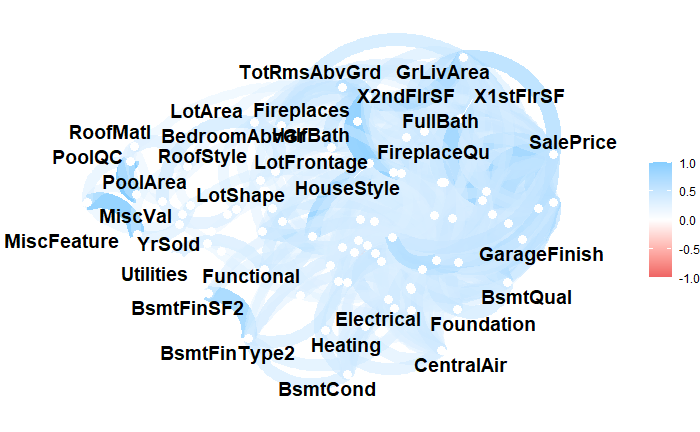

```r
mice_train_assoc %>%
  select(x, y, assoc) %>%
  spread(y, assoc) %>%
  column_to_rownames("x") %>%
  as.matrix %>%
  as_cordf %>%
  network_plot()
```

Clearly, there is a lot of multicollinearity going on. Let’s check the table to see what we can remove.

```r
checkAssoc <- mice_train_assoc[mice_train_assoc$assoc > .7, ]
checkAssoc
```

|  | x | y | assoc | type | complete_obs_pairs | complete_obs_ratio |
| --- | --- | --- | --- | --- | --- | --- |
| Cramer V...1 | MSSubClass | MSSubClass | 1.0000000 | cramersV | 1460 | 1 |
| Cramer V...15 | BldgType | MSSubClass | 0.8914000 | cramersV | 1460 | 1 |
| Cramer V...16 | HouseStyle | MSSubClass | 0.8480000 | cramersV | 1460 | 1 |
| ...44 | X2ndFlrSF | MSSubClass | 0.8999035 | anova | 1460 | 1 |
| Cramer V...82 | MSZoning | MSZoning | 1.0000000 | cramersV | 1460 | 1 |
| ...163 | LotFrontage | LotFrontage | 1.0000000 | correlation | 1460 | 1 |
| ...244 | LotArea | LotArea | 1.0000000 | correlation | 1460 | 1 |
| Cramer V...325 | Street | Street | 1.0000000 | cramersV | 1460 | 1 |
| Cramer V...406 | Alley | Alley | 1.0000000 | cramersV | 1460 | 1 |
| Cramer V...487 | LotShape | LotShape | 1.0000000 | cramersV | 1460 | 1 |

[output cut: 108 more lines]

```r
NA
```

Now we can start dropping the columns that have a high association. This is because the information that these columns carry are already contained in the other column they associate highly with. If we keep it, we may not be able to invert the matrix of the regressors.

```r
mice_train_full <- subset(mice_train_full, select = -c(MiscFeature, PoolQC, BsmtFinType2, BldgType, GrLivArea, HouseStyle, TotalBsmtSF, GarageCars,Exterior2nd, X2ndFlrSF, GarageQual, BsmtFinType1, YearBuilt, BsmtFullBath, GarageFinish, YearRemodAdd))
mice_test_full <- subset(mice_test_full, select = -c(MiscFeature, PoolQC, BsmtFinType2, BldgType, GrLivArea, HouseStyle, TotalBsmtSF, GarageCars,Exterior2nd, X2ndFlrSF, GarageQual, BsmtFinType1, YearBuilt, BsmtFullBath, GarageFinish, YearRemodAdd))
```

Let’s check the associations again to make sure we didn’t miss anything.

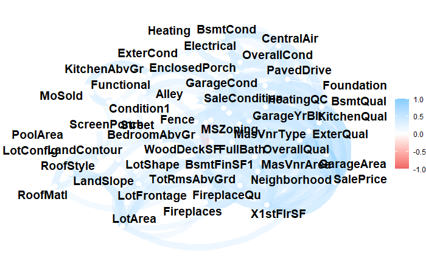

```r
mice_train_assoc <- mixed_assoc(mice_train_full)
mice_train_assoc %>%
  select(x, y, assoc) %>%
  spread(y, assoc) %>%
  column_to_rownames("x") %>%
  as.matrix %>%
  as_cordf %>%
  network_plot()
```

```r
checkAssoc <- mice_train_assoc[mice_train_assoc$assoc > .7, ]
checkAssoc
```

|  | x | y | assoc | type | complete_obs_pairs | complete_obs_ratio |
| --- | --- | --- | --- | --- | --- | --- |
| Cramer V...1 | MSSubClass | MSSubClass | 1.0000000 | cramersV | 1460 | 1 |
| Cramer V...66 | MSZoning | MSZoning | 1.0000000 | cramersV | 1460 | 1 |
| ...131 | LotFrontage | LotFrontage | 1.0000000 | correlation | 1460 | 1 |
| ...196 | LotArea | LotArea | 1.0000000 | correlation | 1460 | 1 |
| Cramer V...261 | Street | Street | 1.0000000 | cramersV | 1460 | 1 |
| Cramer V...326 | Alley | Alley | 1.0000000 | cramersV | 1460 | 1 |
| Cramer V...391 | LotShape | LotShape | 1.0000000 | cramersV | 1460 | 1 |
| Cramer V...456 | LandContour | LandContour | 1.0000000 | cramersV | 1460 | 1 |
| Cramer V...521 | Utilities | Utilities | 1.0000000 | cramersV | 1460 | 1 |
| Cramer V...586 | LotConfig | LotConfig | 1.0000000 | cramersV | 1460 | 1 |

[output cut: 60 more lines]

```r
NA
```

We have just one more high association coefficient remaining.

```r
mice_train_full <- subset(mice_train_full, select = -c(GarageYrBlt))
mice_test_full <- subset(mice_test_full, select = -c(GarageYrBlt))
```

Now we can start building, for this we will be use random forests to start

```r
train.rf <- randomForest(SalePrice ~ ., data=mice_train_full, importance=TRUE, proximity=TRUE)
print(train.rf)
```

```
Call:
 randomForest(formula = SalePrice ~ ., data = mice_train_full,      importance = TRUE, proximity = TRUE)
               Type of random forest: regression
                     Number of trees: 500
No. of variables tried at each split: 15

          Mean of squared residuals: 923399599
                    % Var explained: 85.36
```

```r
n = length(mice_train_full$SalePrice)

PRESS3 = rep(0,100)
for (i in 1:500)
{

  fit = train.rf
  test_data_without_y = mice_test_full
  PRESS3[i] = sum((predict(train.rf,test_data_without_y) - sample_submission$SalePrice)^2)

}

mean(PRESS3)
```

```
[1] 3.600114e+12
```

```r
test_data_without_y$prediction <- predict(train.rf, mice_test_full)
print(test_data_without_y)
```

|  | MSSubClass | MSZoning | LotFrontage | LotArea | Street | Alley | LotShape | LandContour | LotConfig | LandSlope | Neighborhood | Condition1 | OverallQual | OverallCond | RoofStyle | MasVnrArea | ExterQual | ExterCond | Foundation | BsmtQual | BsmtCond | BsmtExposure | BsmtFinSF1 | BsmtFinSF2 | BsmtUnfSF | HeatingQC | CentralAir | X1stFlrSF | LowQualFinSF | … |
| --- | --- | --- | --- | --- | --- | --- | --- | --- | --- | --- | --- | --- | --- | --- | --- | --- | --- | --- | --- | --- | --- | --- | --- | --- | --- | --- | --- | --- | --- | --- |
| 1 | 20 | RH | 80 | 11622 | Pave | 0 | Reg | Lvl | Inside | Gtl | NAmes | Feedr | 5 | 6 | Gable | 0 | TA | TA | CBlock | TA | TA | No | 468 | 144 | 270 | TA | Y | 896 | 0 | … |
| 2 | 20 | RL | 81 | 14267 | Pave | 0 | IR1 | Lvl | Corner | Gtl | NAmes | Norm | 6 | 6 | Hip | 108 | TA | TA | CBlock | TA | TA | No | 923 | 0 | 406 | TA | Y | 1329 | 0 | … |
| 3 | 60 | RL | 74 | 13830 | Pave | 0 | IR1 | Lvl | Inside | Gtl | Gilbert | Norm | 5 | 5 | Gable | 0 | TA | TA | PConc | Gd | TA | No | 791 | 0 | 137 | Gd | Y | 928 | 0 | … |
| 4 | 60 | RL | 78 | 9978 | Pave | 0 | IR1 | Lvl | Inside | Gtl | Gilbert | Norm | 6 | 6 | Gable | 20 | TA | TA | PConc | TA | TA | No | 602 | 0 | 324 | Ex | Y | 926 | 0 | … |
| 5 | 120 | RL | 43 | 5005 | Pave | 0 | IR1 | HLS | Inside | Gtl | StoneBr | Norm | 8 | 5 | Gable | 0 | Gd | TA | PConc | Gd | TA | No | 263 | 0 | 1017 | Ex | Y | 1280 | 0 | … |
| 6 | 60 | RL | 75 | 10000 | Pave | 0 | IR1 | Lvl | Corner | Gtl | Gilbert | Norm | 6 | 5 | Gable | 0 | TA | TA | PConc | Gd | TA | No | 0 | 0 | 763 | Gd | Y | 763 | 0 | … |
| 7 | 20 | RL | 68 | 7980 | Pave | 0 | IR1 | Lvl | Inside | Gtl | Gilbert | Norm | 6 | 7 | Gable | 0 | TA | Gd | PConc | Gd | TA | No | 935 | 0 | 233 | Ex | Y | 1187 | 0 | … |
| 8 | 60 | RL | 63 | 8402 | Pave | 0 | IR1 | Lvl | Inside | Gtl | Gilbert | Norm | 6 | 5 | Gable | 0 | TA | TA | PConc | Gd | TA | No | 0 | 0 | 789 | Gd | Y | 789 | 0 | … |
| 9 | 20 | RL | 85 | 10176 | Pave | 0 | Reg | Lvl | Inside | Gtl | Gilbert | Norm | 7 | 5 | Gable | 0 | TA | TA | PConc | Gd | TA | Gd | 637 | 0 | 663 | Gd | Y | 1341 | 0 | … |
| 10 | 20 | RL | 70 | 8400 | Pave | 0 | Reg | Lvl | Corner | Gtl | NAmes | Norm | 4 | 5 | Gable | 0 | TA | TA | CBlock | TA | TA | No | 804 | 78 | 0 | TA | Y | 882 | 0 | … |

[output cut: 990 more lines]

```r
PRESS_Model3 <- sum((test_data_without_y$prediction - sample_submission$SalePrice)^2)
RMSE_Model3 <- sqrt(mean((test_data_without_y$prediction - sample_submission$SalePrice)^2))
PRESS_Model3
```

```
[1] 3.600114e+12
```

```r
RMSE_Model3
```

```
[1] 49674.16
```

Run a function to display the different factors.

```r
for(attr in colnames(mice_train_full))
{
  if (is.factor(mice_train_full[[attr]]))
  {
    new.levels <- setdiff(levels(mice_train_full[[attr]]), levels(mice_test_full[[attr]]))
    if ( length(new.levels) == 0 )
    { print(paste(attr, '- no new levels')) }
    else
    {
      print(c(paste(attr, length(new.levels), 'of new levels, e.g.'), head(new.levels, 2)))
    }
  }
}
```

[output not shown]

There are many different levels in the testing set that are not present in the training set. This is an issue because we are trying to predict using a variable level that is not accounted for. We cannot predict, using our method of linear regression, a value for SalePrice if we are given a level that our model has not seen before. Therefore, we need to coalesce these levels, or remove them. We will go through right now using partial F-tests to see if some of these are significantly associated with SalePrice.

```r
y1 <- lm(SalePrice~., data = mice_train_full)
summary(y1)

y2 <- lm(SalePrice~.-Utilities, data = mice_train_full)
anova(y2,y1)
```

[output not shown]

We will be doing this for all the variables that have differing levels. If some levels are significantly associated with SalePrice and there is only 1 observation that is different, we shall impute it with the closest possible level. For instance in the Functional category, Sev is most closely related to Maj2 by intuition and therefore we shall use that. This is quite rudimentary and I’m certain there are better ways of dealing with this, but we must proceed. We shall thus correct all the differences in levels as best as possible right now since we want to try and limit the amount that we are forced to get rid of even if they are generally significally associated.

```r
levels(mice_test_full$Fireplaces)[match("4",levels(mice_test_full$Fireplaces))] <- "3"
levels(mice_test_full$MSSubClass)[match("150",levels(mice_test_full$MSSubClass))] <- "120"
levels(mice_test_full$FullBath)[match("4",levels(mice_test_full$FullBath))] <- "3"
levels(mice_test_full$Functional)[match("Sev",levels(mice_test_full$Functional))] <- "Maj2"
levels(mice_test_full$MasVnrType)[match("None",levels(mice_test_full$MasVnrType))] <- "0"


mice_train_full <- subset(mice_train_full, select = -c(Condition2, RoofMatl, Exterior1st, Heating, Electrical, BedroomAbvGr, KitchenAbvGr, KitchenQual, SaleType))
mice_test_full <- subset(mice_test_full, select = -c(Condition2, RoofMatl, Exterior1st, Heating, Electrical, BedroomAbvGr, KitchenAbvGr, KitchenQual, SaleType))

mice_train_full <- subset(mice_train_full, select = -c(TotRmsAbvGrd))
mice_test_full <- subset(mice_test_full, select = -c(TotRmsAbvGrd))


mice_train_full <- subset(mice_train_full, select = -c(Utilities))
mice_test_full <- subset(mice_test_full, select = -c(Utilities))


mice_train_full <- subset(mice_train_full, select = -c(Functional, MoSold, YrSold, MasVnrType))
mice_test_full <- subset(mice_test_full, select = -c(Functional, MoSold, YrSold, MasVnrType))

mice_train_full <- subset(mice_train_full, select = -c(HalfBath , BsmtHalfBath))
mice_test_full <- subset(mice_test_full, select = -c(HalfBath , BsmtHalfBath))
```

We are now done with correcting the levels. Let’s run the random forest again and then we can proceed with using it on the testing data to calculate our RMSE.

```r
train.rf <- randomForest(SalePrice ~ ., data=mice_train_full, importance=TRUE, proximity=TRUE)
print(train.rf)
```

```r
n = length(mice_train_full$SalePrice)

PRESS = rep(0,100)
for (i in 1:500)
{

  fit = train.rf
  test_data_without_y = mice_test_full
  PRESS[i] = sum((predict(train.rf,test_data_without_y) - sample_submission$SalePrice)^2)

}

test_data_without_y$prediction <- predict(train.rf, mice_test_full)
print(test_data_without_y)

PRESS_Model <- sum((test_data_without_y$prediction - sample_submission$SalePrice)^2)
RMSE_Model <- sqrt(mean((test_data_without_y$prediction - sample_submission$SalePrice)^2))
PRESS_Model
RMSE_Model
```

[output not shown]

```r
mice_train_full <- subset(mice_train_full, select = -c(HalfBath , BsmtHalfBath))
mice_test_full <- subset(mice_test_full, select = -c(HalfBath , BsmtHalfBath))
```

```r
levels(mice_test_full$Fireplaces)[match("4",levels(mice_test_full$Fireplaces))] <- "3"
levels(mice_test_full$MSSubClass)[match("150",levels(mice_test_full$MSSubClass))] <- "120"
levels(mice_test_full$FullBath)[match("4",levels(mice_test_full$FullBath))] <- "3"
levels(mice_test_full$Functional)[match("Sev",levels(mice_test_full$Functional))] <- "Maj2"
levels(mice_test_full$MasVnrType)[match("None",levels(mice_test_full$MasVnrType))] <- "0"


mice_train_full <- subset(mice_train_full, select = -c(Condition2, RoofMatl, Exterior1st, Heating, Electrical, BedroomAbvGr, KitchenAbvGr, KitchenQual, SaleType))
mice_test_full <- subset(mice_test_full, select = -c(Condition2, RoofMatl, Exterior1st, Heating, Electrical, BedroomAbvGr, KitchenAbvGr, KitchenQual, SaleType))

mice_train_full <- subset(mice_train_full, select = -c(TotRmsAbvGrd))
mice_test_full <- subset(mice_test_full, select = -c(TotRmsAbvGrd))


mice_train_full <- subset(mice_train_full, select = -c(Utilities))
mice_test_full <- subset(mice_test_full, select = -c(Utilities))


mice_train_full <- subset(mice_train_full, select = -c(Functional, MoSold, YrSold, MasVnrType))
mice_test_full <- subset(mice_test_full, select = -c(Functional, MoSold, YrSold, MasVnrType))
```

```r
train.rf <- randomForest(SalePrice ~ ., data=mice_train_full, importance=TRUE, proximity=TRUE)
print(train.rf)
```

[output not shown]

```r
n = length(mice_train_full$SalePrice)

PRESS4 = rep(0,100)
for (i in 1:500)
{

  fit = train.rf
  test_data_without_y = mice_test_full
  PRESS3[i] = sum((predict(train.rf,test_data_without_y) - sample_submission$SalePrice)^2)

}

test_data_without_y$prediction <- predict(train.rf, mice_test_full)
print(test_data_without_y)

PRESS_Model4 <- sum((test_data_without_y$prediction - sample_submission$SalePrice)^2)
RMSE_Model4 <- sqrt(mean((test_data_without_y$prediction - sample_submission$SalePrice)^2))
PRESS_Model4
RMSE_Model4
```

[output not shown]